# **Problem Statement**

# **Model Performance Improvement - Hyperparameter Tuning**

## Hyperparameter Tuning - Random Forest

```python
rf_tuned_model = Pipeline(
    steps=[
        ("preprocessor", preprocessor),
        ("model", RandomForestClassifier(random_state=1, class_weight="balanced")),
    ]
)

rf_parameters = {
    "model__n_estimators": [100, 200],
    "model__max_depth": [4, 6, 8, None],
    "model__min_samples_split": [2, 5, 10],
    "model__min_samples_leaf": [1, 2, 4],
    "model__max_features": ["sqrt", None],
}

rf_grid = GridSearchCV(
    estimator=rf_tuned_model,
    param_grid=rf_parameters,
    scoring="f1",
    cv=5,
    n_jobs=-1,
)

rf_grid.fit(X_train, y_train)

print("Best parameters:", rf_grid.best_params_)
print("Best cross-validation F1-score:", rf_grid.best_score_)

tuned_rf_model = rf_grid.best_estimator_
```

```
Best parameters: {'model__max_depth': None, 'model__max_features': 'sqrt', 'model__min_samples_leaf': 2, 'model__min_samples_split': 10, 'model__n_estimators': 100}
Best cross-validation F1-score: 0.7797130130018683
```

**Hyperparameter Tuning Observations**

- The best model used **100 estimators**, meaning the random forest was built with 100 trees.
- `max_depth=None` allows the trees to grow fully, which can capture complex patterns in the data.
- `max_features='sqrt'` means each tree considers only a subset of features at each split, helping reduce overfitting.
- `min_samples_leaf=2` and `min_samples_split=10` add some regularization, preventing the trees from splitting too aggressively.
- The best cross-validation **F1-score is 0.7797**, or about **78.0%**.
- This suggests the tuned model performs well and balances precision and recall reasonably.
- Since the tuned cross-validation F1-score is close to the earlier test F1-score, the model appears to generalize fairly well.
- Overall, the tuned Random Forest is likely one of the stronger models for this dataset.

### Checking model performance on training set

|  | Accuracy | Recall | Precision | F1 |
| --- | --- | --- | --- | --- |
| 0 | 0.918216 | 0.917012 | 0.827715 | 0.870079 |

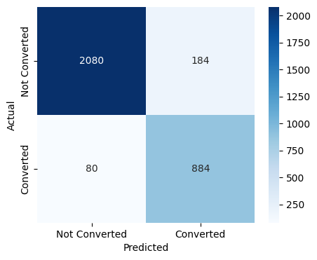

```python
tuned_rf_train_perf = model_performance_classification(tuned_rf_model, X_train, y_train)
display(tuned_rf_train_perf)
confusion_matrix_sklearn(tuned_rf_model, X_train, y_train)
```

**Tuned Model Performance Observations**

### Checking model performance on test set

|  | Accuracy | Recall | Precision | F1 |
| --- | --- | --- | --- | --- |
| 0 | 0.856936 | 0.791768 | 0.744875 | 0.767606 |

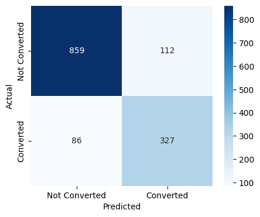

```python
tuned_rf_test_perf = model_performance_classification(tuned_rf_model, X_test, y_test)
display(tuned_rf_test_perf)
confusion_matrix_sklearn(tuned_rf_model, X_test, y_test)
```

**Model Performance Observations**

## Hyperparameter Tuning - AdaBoost Classifier

```python
adaboost_tuned_model = Pipeline(
    steps=[
        ("preprocessor", preprocessor),
        ("model", AdaBoostClassifier(random_state=1)),
    ]
)

adaboost_parameters = {
    "model__estimator": [
        DecisionTreeClassifier(max_depth=1, random_state=1),
        DecisionTreeClassifier(max_depth=2, random_state=1),
        DecisionTreeClassifier(max_depth=3, random_state=1),
    ],
    "model__n_estimators": [50, 100, 150],
    "model__learning_rate": [0.01, 0.05, 0.1, 0.5, 1.0],
}

adaboost_grid = GridSearchCV(
    estimator=adaboost_tuned_model,
    param_grid=adaboost_parameters,
    scoring="f1",
    cv=5,
    n_jobs=-1,
)

adaboost_grid.fit(X_train, y_train)

print("Best parameters:", adaboost_grid.best_params_)
print("Best cross-validation F1-score:", adaboost_grid.best_score_)

tuned_adaboost_model = adaboost_grid.best_estimator_
```

```
Best parameters: {'model__estimator': DecisionTreeClassifier(max_depth=3, random_state=1), 'model__learning_rate': 0.5, 'model__n_estimators': 100}
Best cross-validation F1-score: 0.7648426197353182
```

**Boosting Model Tuning Observations**

- The best boosting model used a **Decision Tree with `max_depth=3`** as the base estimator.
- It used **100 estimators**, meaning 100 weak learners were combined.
- The best `learning_rate` was **0.5**, which controls how strongly each new learner contributes to the final model.
- The best cross-validation **F1-score is 0.7648**, or about **76.5%**.
- This is a reasonable result, but it is lower than the tuned Random Forest cross-validation F1-score of about **78.0%**.
- The model may generalize fairly well, but based on cross-validation, it is not the strongest model so far.
- Overall, the tuned boosting model performs well, but the tuned Random Forest still appears to be the better option.

### Checking model performance on training set

|  | Accuracy | Recall | Precision | F1 |
| --- | --- | --- | --- | --- |
| 0 | 0.86772 | 0.766598 | 0.785335 | 0.775853 |

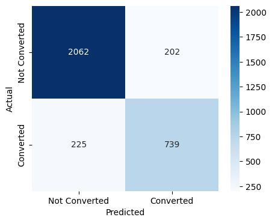

```python
tuned_adaboost_train_perf = model_performance_classification(tuned_adaboost_model, X_train, y_train)
display(tuned_adaboost_train_perf)
confusion_matrix_sklearn(tuned_adaboost_model, X_train, y_train)
```

**Tuned Boosting Model Performance Observations**

### Checking model performance on test set

|  | Accuracy | Recall | Precision | F1 |
| --- | --- | --- | --- | --- |
| 0 | 0.864162 | 0.757869 | 0.780549 | 0.769042 |

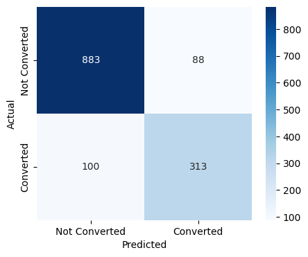

```python
tuned_adaboost_test_perf = model_performance_classification(tuned_adaboost_model, X_test, y_test)
display(tuned_adaboost_test_perf)
confusion_matrix_sklearn(tuned_adaboost_model, X_test, y_test)
```

**Model Performance Observations**

# **Model Performance Comparison, Final Model Selection, and Serialization**

```python
models_train_comp_df = pd.concat(
    [
        rf_train_perf.T,
        adaboost_train_perf.T,
        tuned_rf_train_perf.T,
        tuned_adaboost_train_perf.T,
    ],
    axis=1,
)
models_train_comp_df.columns = [
    "Random Forest",
    "AdaBoost",
    "Tuned Random Forest",
    "Tuned AdaBoost",
]
print("Training performance comparison")
display(models_train_comp_df)

models_test_comp_df = pd.concat(
    [
        rf_test_perf.T,
        adaboost_test_perf.T,
        tuned_rf_test_perf.T,
        tuned_adaboost_test_perf.T,
    ],
    axis=1,
)
models_test_comp_df.columns = [
    "Random Forest",
    "AdaBoost",
    "Tuned Random Forest",
    "Tuned AdaBoost",
]
print("Test performance comparison")
display(models_test_comp_df)

if tuned_adaboost_test_perf.loc[0, "F1"] >= tuned_rf_test_perf.loc[0, "F1"]:
    final_model = tuned_adaboost_model
    final_model_name = "Tuned AdaBoost"
else:
    final_model = tuned_rf_model
    final_model_name = "Tuned Random Forest"

print("Final selected model:", final_model_name)

try:
    feature_names = final_model.named_steps["preprocessor"].get_feature_names_out()
    importances = final_model.named_steps["model"].feature_importances_
    importance_df = (
        pd.DataFrame({"Feature": feature_names, "Importance": importances})
        .sort_values("Importance", ascending=False)
        .head(20)
    )
    display(importance_df)
except Exception as exc:
    print("Feature importance could not be generated:", exc)

os.makedirs("backend_files", exist_ok=True)

model_bundle = {
    "model": final_model,
    "features": X.columns.tolist(),
    "categorical_features": categorical_features,
    "numeric_features": numeric_features,
    "target": "status",
    "model_name": final_model_name,
}

joblib.dump(model_bundle, "model.joblib")
joblib.dump(model_bundle, "backend_files/model.joblib")
print("Model serialized as model.joblib and backend_files/model.joblib")
```

```
Training performance comparison
```

|  | Random Forest | AdaBoost | Tuned Random Forest | Tuned AdaBoost |
| --- | --- | --- | --- | --- |
| Accuracy | 0.999380 | 0.810099 | 0.918216 | 0.867720 |
| Recall | 1.000000 | 0.558091 | 0.917012 | 0.766598 |
| Precision | 0.997930 | 0.742069 | 0.827715 | 0.785335 |
| F1 | 0.998964 | 0.637063 | 0.870079 | 0.775853 |

```
Test performance comparison
```

|  | Random Forest | AdaBoost | Tuned Random Forest | Tuned AdaBoost |
| --- | --- | --- | --- | --- |
| Accuracy | 0.859104 | 0.825145 | 0.856936 | 0.864162 |
| Recall | 0.723971 | 0.585956 | 0.791768 | 0.757869 |
| Precision | 0.786842 | 0.773163 | 0.744875 | 0.780549 |
| F1 | 0.754098 | 0.666667 | 0.767606 | 0.769042 |

```
Final selected model: Tuned AdaBoost
```

|  | Feature | Importance |
| --- | --- | --- |
| 2 | num__time_spent_on_website | 3.084545e-01 |
| 7 | cat__first_interaction_Mobile App | 1.473394e-01 |
| 8 | cat__first_interaction_Website | 9.760048e-02 |
| 0 | num__age | 7.118904e-02 |
| 11 | cat__profile_completed_Medium | 6.044096e-02 |
| 1 | num__website_visits | 5.480122e-02 |
| 9 | cat__profile_completed_High | 5.196221e-02 |
| 3 | num__page_views_per_visit | 5.066605e-02 |
| 4 | cat__current_occupation_Professional | 3.555130e-02 |
| 10 | cat__profile_completed_Low | 2.333200e-02 |
| 23 | cat__referral_No | 1.819995e-02 |
| 14 | cat__last_activity_Website Activity | 1.770110e-02 |
| 13 | cat__last_activity_Phone Activity | 1.735953e-02 |
| 24 | cat__referral_Yes | 1.699624e-02 |
| 6 | cat__current_occupation_Unemployed | 1.505791e-02 |
| 12 | cat__last_activity_Email Activity | 9.706302e-03 |
| 15 | cat__print_media_type1_No | 3.186340e-03 |
| 22 | cat__educational_channels_Yes | 4.554523e-04 |
| 21 | cat__educational_channels_No | 1.982797e-16 |
| 17 | cat__print_media_type2_No | 6.690757e-17 |

```
Model serialized as model.joblib and backend_files/model.joblib
```

**Final Model Comparison Observations**

- The original Random Forest performed almost perfectly on training data, with an F1-score of **0.999**, but dropped to **0.754** on test data. This suggests **overfitting**.
- AdaBoost had the weakest performance overall, especially with test recall of **0.586** and F1-score of **0.667**.
- Tuned Random Forest improved recall on the test set to **0.792**, making it better at identifying actual positive cases.
- Tuned AdaBoost achieved the best overall test performance, with:
  - Accuracy: **86.42%**
  - Recall: **75.79%**
  - Precision: **78.05%**
  - F1-score: **76.90%**
- Tuned AdaBoost has the highest test F1-score, but only slightly higher than Tuned Random Forest. So the final choice is reasonable, especially if balanced performance and precision are important.
- If the main business goal is to capture as many positive leads as possible, Tuned Random Forest could also be considered because it has higher recall.

**Feature Importance Observations**

- `time_spent_on_website` is the most important predictor, contributing about **30.8%** importance.
- `first_interaction` is highly influential, especially whether the user first interacted through the **Mobile App** or **Website**.
- `age`, `profile_completed`, `website_visits`, and `page_views_per_visit` also contribute meaningfully to prediction.
- Profile completion matters: users with different completion levels show different likelihoods of conversion.
- Referral has some predictive value, but its importance is lower than expected, likely because referral users are a very small group.
- Print media, digital media, and educational channel features have very low importance, suggesting they add little predictive value to the final model.

Overall, the **Tuned AdaBoost model** is a strong final choice, with `time_spent_on_website`, `first_interaction`, and `profile_completed` emerging as the most important drivers of conversion.

# **Deployment - Backend**

## Flask Web Framework

```python
%%writefile backend_files/app.py
from pathlib import Path

import joblib
import pandas as pd
from flask import Flask, jsonify, request


MODEL_PATH = Path(__file__).with_name("model.joblib")
MODEL_BUNDLE = joblib.load(MODEL_PATH)
MODEL = MODEL_BUNDLE["model"]
FEATURES = MODEL_BUNDLE["features"]

app = Flask(__name__)


def _payload_to_frame(payload):
    if isinstance(payload, dict):
        records = payload.get("data", payload)
    elif isinstance(payload, list):
        records = payload
    else:
        raise ValueError("Payload must be a JSON object or a list of objects.")

    if isinstance(records, dict):
        records = [records]

    frame = pd.DataFrame(records)
    missing = [column for column in FEATURES if column not in frame.columns]
    if missing:
        raise ValueError(f"Missing required field(s): {', '.join(missing)}")

    return frame[FEATURES]


@app.get("/")
def health_check():
    return jsonify(
        {
            "status": "ok",
            "model": MODEL_BUNDLE.get("model_name", "ExtraaLearn lead conversion model"),
            "features": FEATURES,
        }
    )


@app.post("/predict")
def predict():
    try:
        payload = request.get_json(force=True)
        input_data = _payload_to_frame(payload)
        predictions = MODEL.predict(input_data).astype(int).tolist()

        if hasattr(MODEL, "predict_proba"):
            probabilities = MODEL.predict_proba(input_data)[:, 1].round(4).tolist()
        else:
            probabilities = [None] * len(predictions)

        results = [
            {
                "prediction": prediction,
                "prediction_label": "Converted" if prediction == 1 else "Not Converted",
                "conversion_probability": probability,
            }
            for prediction, probability in zip(predictions, probabilities)
        ]
        return jsonify({"results": results})
    except Exception as exc:
        return jsonify({"error": str(exc)}), 400


if __name__ == "__main__":
    app.run(host="0.0.0.0", port=7860)
```

```
Writing backend_files/app.py
```

## Dependencies File

```python
%%writefile backend_files/requirements.txt
flask==3.0.3
joblib==1.4.2
numpy==2.0.2
pandas==2.2.2
scikit-learn==1.6.1
```

```
Writing backend_files/requirements.txt
```

## Dockerfile

```python
%%writefile backend_files/Dockerfile
FROM python:3.9-slim

WORKDIR /app

COPY . .

RUN pip install --no-cache-dir -r requirements.txt

EXPOSE 7860

CMD ["python", "app.py"]
```

```
Writing backend_files/Dockerfile
```

```python
import os
import joblib

os.makedirs("backend_files", exist_ok=True)

model_bundle = {
    "model": final_model,
    "features": X.columns.tolist(),
    "categorical_features": categorical_features,
    "numeric_features": numeric_features,
    "target": "status",
    "model_name": final_model_name,
}

joblib.dump(model_bundle, "model.joblib")
joblib.dump(model_bundle, "backend_files/model.joblib")

print("Model saved:", os.path.exists("model.joblib"))
print("Backend model saved:", os.path.exists("backend_files/model.joblib"))
```

```
Model saved: True
Backend model saved: True
```

```python
import os
import shutil

os.makedirs("backend_files", exist_ok=True)

# If model.joblib exists in the main Colab folder, copy it into backend_files
if os.path.exists("model.joblib"):
    shutil.copy("model.joblib", "backend_files/model.joblib")

print(os.listdir("backend_files"))
print("Model exists:", os.path.exists("backend_files/model.joblib"))
```

```
['Dockerfile', 'model.joblib', 'requirements.txt', 'app.py']
Model exists: True
```

## Setting up a Hugging Face Docker Space for the Backend

**Note**: We are creating a Hugging Face Docker Space for our backend using the Hugging Face Hub API. This automates the space creation process and enables seamless deployment of our Flask app.

```python
# Authenticate with Hugging Face.
import os
from huggingface_hub import login, HfApi
from google.colab import userdata
hf_token = userdata.get("HF_TOKEN")

try:
    from google.colab import userdata
    hf_token = hf_token or userdata.get("HF_TOKEN")
except Exception:
    pass

if not hf_token:
    raise ValueError("Please set HF_TOKEN before creating or uploading to Hugging Face Spaces.")

login(token=hf_token)
api = HfApi()

me = api.whoami(token=hf_token)
```

**Note :** If you were trying with different names, be cautious when using a underscore `_` in space names, such as `frontend_space`, as it can cause exceptions when accessing the API. Always use an hyphen `-` instead, like `frontend-space`.

```python
HF_USERNAME = me["name"]
BACKEND_SPACE_NAME = "extraalearn-backend"
backend_space_id = f"{HF_USERNAME}/{BACKEND_SPACE_NAME}"

api.create_repo(
    repo_id=backend_space_id,
    repo_type="space",
    space_sdk="docker",
    exist_ok=True,
    private=False,
)

print("Backend Space:", backend_space_id)
print("Backend API URL:", f"https://{HF_USERNAME}-{BACKEND_SPACE_NAME}.hf.space")
```

```
Backend Space: omohemma/extraalearn-backend
Backend API URL: https://omohemma-extraalearn-backend.hf.space
```

## Uploading Files to Hugging Face Space (Docker Space)

**Note**: Before running the code below, ensure that the serialized ML model has been uploaded in to `backend_files` folder.

```python
# Ensure backend_files contains app.py, requirements.txt, Dockerfile, and model.joblib before running this cell.
api.upload_folder(
    folder_path="backend_files",
    repo_id=backend_space_id,
    repo_type="space",
)

print("Backend files uploaded successfully.")
```

```
Backend files uploaded successfully.
```

# **Deployment - Frontend**

## Points to note before executing the below cells

- Create a Streamlit space on Hugging Face by following the instructions provided on the content page titled **`Creating Spaces and Adding Secrets in Hugging Face`** from Week 1

## Streamlit for Interactive UI

```python
%%writefile frontend_files/app.py
import os

import pandas as pd
import requests
import streamlit as st


DEFAULT_BACKEND_URL = os.getenv("BACKEND_URL", "").rstrip("/")

st.set_page_config(page_title="ExtraaLearn Lead Conversion", page_icon="EL", layout="centered")
st.title("ExtraaLearn Lead Conversion")

backend_url = st.sidebar.text_input("Backend URL", value=DEFAULT_BACKEND_URL)

tab_single, tab_batch = st.tabs(["Single Lead", "Batch Scoring"])

with tab_single:
    age = st.number_input("Age", min_value=18, max_value=80, value=35, step=1)
    current_occupation = st.selectbox("Current Occupation", ["Professional", "Unemployed", "Student"])
    first_interaction = st.selectbox("First Interaction", ["Website", "Mobile App"])
    profile_completed = st.selectbox("Profile Completed", ["Low", "Medium", "High"], index=2)
    website_visits = st.number_input("Website Visits", min_value=0, max_value=50, value=5, step=1)
    time_spent_on_website = st.number_input(
        "Time Spent on Website", min_value=0, max_value=5000, value=700, step=10
    )
    page_views_per_visit = st.number_input(
        "Page Views per Visit", min_value=0.0, max_value=25.0, value=3.0, step=0.1
    )
    last_activity = st.selectbox(
        "Last Activity", ["Website Activity", "Email Activity", "Phone Activity"]
    )
    print_media_type1 = st.selectbox("Newspaper Ad", ["No", "Yes"])
    print_media_type2 = st.selectbox("Magazine Ad", ["No", "Yes"])
    digital_media = st.selectbox("Digital Media Ad", ["No", "Yes"])
    educational_channels = st.selectbox("Educational Channels", ["No", "Yes"])
    referral = st.selectbox("Referral", ["No", "Yes"])

    payload = {
        "age": age,
        "current_occupation": current_occupation,
        "first_interaction": first_interaction,
        "profile_completed": profile_completed,
        "website_visits": website_visits,
        "time_spent_on_website": time_spent_on_website,
        "page_views_per_visit": page_views_per_visit,
        "last_activity": last_activity,
        "print_media_type1": print_media_type1,
        "print_media_type2": print_media_type2,
        "digital_media": digital_media,
        "educational_channels": educational_channels,
        "referral": referral,
    }

    if st.button("Predict Conversion", type="primary"):
        if not backend_url:
            st.error("Backend URL is required.")
        else:
            response = requests.post(f"{backend_url}/predict", json=payload, timeout=30)
            if response.ok:
                result = response.json()["results"][0]
                probability = result.get("conversion_probability")
                st.metric("Prediction", result["prediction_label"])
                if probability is not None:
                    st.metric("Conversion Probability", f"{probability:.1%}")
            else:
                st.error(response.json().get("error", response.text))

with tab_batch:
    uploaded_file = st.file_uploader("Upload Leads CSV", type=["csv"])
    if uploaded_file is not None:
        batch_data = pd.read_csv(uploaded_file)
        st.dataframe(batch_data.head(), use_container_width=True)

        if st.button("Score Batch"):
            if not backend_url:
                st.error("Backend URL is required.")
            else:
                records = batch_data.to_dict(orient="records")
                response = requests.post(f"{backend_url}/predict", json={"data": records}, timeout=60)
                if response.ok:
                    results = pd.DataFrame(response.json()["results"])
                    scored_data = pd.concat([batch_data.reset_index(drop=True), results], axis=1)
                    st.dataframe(scored_data, use_container_width=True)
                    st.download_button(
                        "Download Scores",
                        scored_data.to_csv(index=False).encode("utf-8"),
                        "extraalearn_predictions.csv",
                        "text/csv",
                    )
                else:
                    st.error(response.json().get("error", response.text))
```

```
Overwriting frontend_files/app.py
```

## Dependencies File

```python
%%writefile frontend_files/requirements.txt
streamlit==1.44.1
pandas==2.2.2
requests==2.32.3
```

```
Writing frontend_files/requirements.txt
```

## Dockerfile

```python
%%writefile frontend_files/Dockerfile
FROM python:3.9-slim

WORKDIR /app

COPY . .

RUN pip3 install --no-cache-dir -r requirements.txt

EXPOSE 8501

CMD ["streamlit", "run", "app.py", "--server.port=8501", "--server.address=0.0.0.0", "--server.enableXsrfProtection=false"]
```

```
Writing frontend_files/Dockerfile
```

## Uploading Files to Hugging Face Space (Streamlit Space)

```python
# Create a Streamlit Space manually on Hugging Face or use the code below.
# Add BACKEND_URL as a Space secret, for example:
# https://your-huggingface-username-extraalearn-backend.hf.space

FRONTEND_SPACE_NAME = "extraalearn-frontend"
frontend_space_id = f"{HF_USERNAME}/{FRONTEND_SPACE_NAME}"

api.create_repo(
    repo_id=frontend_space_id,
    repo_type="space",
    space_sdk="docker",
    exist_ok=True,
    private=False,
)

api.upload_folder(
    folder_path="frontend_files",
    repo_id=frontend_space_id,
    repo_type="space",
)

print("Frontend files uploaded successfully.")
print("Frontend Space:", frontend_space_id)
FRONTEND_SPACE_NAME = "extraalearn-frontend"
print("Frontend URL:", f"https://{HF_USERNAME}-{FRONTEND_SPACE_NAME}.hf.space")
```

```
No files have been modified since last commit. Skipping to prevent empty commit.
WARNING:huggingface_hub.hf_api:No files have been modified since last commit. Skipping to prevent empty commit.
```

```
Frontend files uploaded successfully.
Frontend Space: omohemma/extraalearn-frontend
Frontend URL: https://omohemma-extraalearn-frontend.hf.space
```

# **Actionable Insights and Business Recommendations**

- The dataset contains **4,612 leads**, with about **29.86%** converting to paid customers. This shows that conversion is not evenly distributed, so lead prioritization is important.
- Leads whose first interaction was through the **Website** had a much higher conversion rate than leads from the Mobile App. ExtraaLearn should strengthen website-based campaigns and study why mobile app leads convert less.
- Leads with **High profile completion** were more likely to convert. The company should encourage users to complete their profiles through reminders, progress prompts, and simplified onboarding.
- **Referral leads** showed the strongest conversion behavior. ExtraaLearn should invest more in referral programs, incentives, and quick follow-up for referred leads.
- Converted leads spent more time on the website than non-converted leads. Time spent on website should be treated as a strong buying-intent signal for sales prioritization.
- The final selected model can help the sales team rank leads based on conversion probability, allowing representatives to focus first on leads with the highest likelihood of conversion.
- ExtraaLearn should use batch scoring regularly to refresh lead priority lists and monitor model performance over time as customer behavior changes.